Translational challenges of remote ischemic conditioning in

ischemic stroke – a systematic review

Line Fuglsang Hansen<sup>1,2</sup>, Nicholine S. K. Nielsen<sup>1</sup>, Laura Cathrine Christoffersen<sup>1</sup>&

Christina Kruuse<sup>1,3</sup>

1Department of Neurology, Neurovascular Research Unit, Herlev Gentofte Hospital, Copenhagen, Denmark

2Department of Anesthesiology and Intensive Care, Holbaek Hospital, Holbaek, Denmark

3Department. of Clinical Medicine, University of Copenhagen, Copenhagen, Denmark

Correspondence

Christina Kruuse, Department of Neurology,

Neurovascular Research Unit, University of

Copenhagen, Borgmester Ib Juuls Vej 1, DK-

2730 Herlev, Herlev og Gentofte Hospital,

Copenhagen, Denmark. Tel: +4538681233;

E-mail: ckruuse@dadlnet.dk

Funding Information

CK was supported by a grant from Novo

Nordisk Foundation (Borregaard Stipend,

NNF18OC0031840), LC was supported by a

research scholarship from Lundbeck

Foundation.

Received: 11 February 2021; Revised: 20

April 2021; Accepted: 19 May 2021

Annals of Clinical and Translational

Neurology 2021; 8(8): 1720–1729

doi: 10.1002/acn3.51405

Abstract

Remote ischemic conditioning (RIC) has well-established cardioprotective

effects in preclinical studies and promising results in preclinical stroke research.

Effective translation from preclinical studies to clinical trials has yet to be

accomplished, perhaps because of the use of multiple applications of RIC (e.g.,

pre-, per-, or post-conditioning) in preclinical studies by both invasive and

non-invasive protocols, some of which not clinically applicable. Our systematic

review conformed to PRISMA guidelines and addressed differences in clinically

relevant RIC applications and outcomes between preclinical and clinical studies.

We retrieved a total of 30 studies (8 human; 22 animal) that met the inclusion

criteria of testing clinically relevant procedures; namely, non-invasive and per-

or post-conditioning protocols. Per-conditioning was applied in 6 animal and 3

human studies, post-conditioning was applied in 16 animal and 5 human stud-

ies, and both conditioning methods were applied in 2 animal studies. Applica-

tion of RIC varied between human and animal studies regarding initiation,

duration, repetition, and number of limbs included. Study designs did not sys-

tematically apply blinding, randomization, or placebo controls. On only a few

occasions did preclinical studies include animals with clinically relevant comor-

bidities. Clinical trials were challenged by not completing the intended number

of RIC cycles or addressing this deﬁcit in the data analysis. Consistency and

transferability of methods used for positive animal studies and subsequent

human studies are essential for the optimal translation of results. Consensus on

preclinical and clinical RIC procedures should be reached for a full understand-

ing of the possible beneﬁcial effects of RIC treatment in stroke.

Introduction

Remote

ischemic

conditioning

(RIC),

performed

by

applying non-fatal, short, intermittent ischemia on a limb,

could be a promising new add-on treatment of cardio-

and cerebrovascular ischemic diseases. In experiments

using animals with induced ischemic stroke, RIC reduces

ischemic lesions, improves neurological outcome, and can

be applied before (remote ischemic pre-conditioning;

RIPreC),

during

(remote

ischemic

per-conditioning;

RIPerC) the ischemic event or after reperfusion (remote

ischemic post-conditioning; RIPostC).<sup>1</sup><sup>–</sup><sup>3</sup>

Notwithstanding new advances in reperfusion therapy,

cerebrovascular disease is a major cause of disability and

death in the Western world.<sup>4</sup>Reperfusion therapy is

only available for the smaller number of patients who

receive timely medical care, so new treatments are highly

warranted. RIC treatment shows positive effects in ani-

mal stroke models, but effects do not translate well into

clinical results, as noted in a recent meta-analysis of

seven clinical trials that found no consistent effect on

stroke outcome.<sup>5</sup>Such data call for a review of methods

applied in preclinical studies to address pitfalls in proce-

dures that challenge the translation of preclinical results

to human studies and to improve preclinical data prior

to clinical trials.

In

general,

the

challenge

of

translating

treatment

effects on stroke from animal studies to human trials is

often ascribed to non-physiological experimental condi-

tions in animals that do not reﬂect human conditions.<sup>6</sup>

1720

Most animal experiments apply RIC in pre-conditioning

protocols, which is highly relevant in situations where

ischemia may be anticipated, such as during cardiac or

vascular surgery.<sup>7,8</sup>Valuable results on the effects of pre-

conditioning have been achieved and tested in humans.<sup>9</sup>

However,

in

medical

conditions

with

unpredictable

onset,

such

as

acute

stroke,

results

from

the

pre-

conditioning studies may be less applicable, and results

from per-or post-conditioning more likely to mimic the

clinical

condition.

Tests

of

pre-,

per-,

and

post-

conditioning regimens of RIC show that each application

elicits contradictory ﬁndings or varying levels of effec-

tiveness.<sup>3,10,11</sup>Invasive and non-invasive methods are

applied in administering RIC, which may impact elicited

physiological responses differently.

Though lacking comparability, results from these very

methodically diverse studies have led to conclusions on

the efﬁcacy of RIC also in humans.<sup>12,13</sup>Non-invasive per-

or postconditioning RIC protocol would be the most rele-

vant application in human acute stroke, and results from

applying these conditions in animals would be most rele-

vant to translate to human use.

In this review, we focused on methods reported in pos-

itive preclinical studies that test clinically relevant applica-

tions of RIC for acute stroke. We aimed to determine the

comparability of trial procedures to those of human trials

to further optimize both preclinical and human studies

and disclose possible beneﬁcial effects of RIC in stroke

treatment (Fig. 1).

Methods

Electronic search

The electronic search followed the Preferred Reporting

Items for Systematic Reviews and Meta-Analyses (PRISMA)

guidelines in MEDLINE and Embase.<sup>14</sup>A search string was

developed and revised by three reviewers (LH, LC, and

CK). Reference lists of included papers were searched for

other relevant studies. The search strategy combined terms

for stroke and ischemic conditioning, including relevant

MeSH

terms

(MEDLINE)

or

Map

terms

(Embase)

(Fig. S1). Only studies on focal ischemic stroke were

included in the ﬁnal data processing. The ﬁnal electronic

search was performed on March 30, 2020 (LH and NN).

Study selection

Inclusion criteria consisted of studies investigating RIPerC

or RIPostC in animal stroke models or patients with

acute focal ischemic stroke. Exclusion criteria included

review studies, studies that were written in languages

other than Danish or English, investigated only RIPreC,

used an invasive RIC protocol or global ischemia/asphyxia

models, and studies investigating hemorrhagic stroke or

subarachnoid hemorrhage. The electronic data search gen-

erated 1811 hits (Fig. S2). All papers were transferred into

the web-based review-screening tool Covidence (Covi-

dence, Melbourne, Australia). After the electronic removal

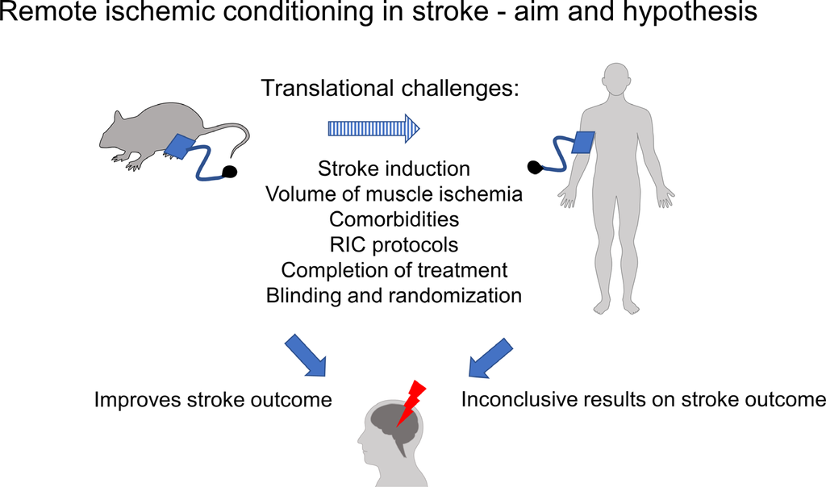

Figure 1. Graphic presentation of aim and hypothesis. Translation of preclinical positive data may be challenged by a multitude of factors

accounting for unresolved effects in clinical trials.

1721

L.F. Hansen et al.

Translational Challenges of RIC in Stroke

of duplicates, two reviewers (LH and NN) screened titles

and abstracts and read the full text to assess the eligibility

of papers. Disagreements were resolved by consensus and

a third reviewer (CK).

One of the 10 studies lacking details of the RIC proce-

dure was included in our analysis after the authors provided

the details. The most frequent cause of exclusion was the

use of an invasive RIC protocol. Regular meta-analysis was

not possible because data from the selected papers had

highly variable outcome measures and result reporting.

Results

Full-text screening resulted in 30 papers comprising 22

animal experiments and 8 clinical trials (Fig. 2).

Methods applied in animal experiments

Methodology varied between studies (Tables 1–3 and

Table S1).

Focal cerebral ischemia was induced by the unilateral

ﬁlament middle cerebral artery occlusion (MCAO) model

in the majority of studies (Table 1).<sup>1</sup><sup>–</sup><sup>3,10,11,15</sup><sup>–</sup><sup>29</sup>The

duration of MCAO (and thus size of induced lesions)

varied from 30 to 120 min, with 60<sup>2,18,23,24,26</sup><sup>–</sup><sup>28</sup>or

90<sup>1,15,16,20,21,25,29</sup>min of occlusion being the most com-

mon duration. Only two studies used the MCAO embolic

model (embolic stroke is induced by the injection of a

homologous

blood

clot

into

the

middle

cerebral

artery).<sup>30,31</sup>Anesthetics were used during MCAO in all

studies; most used chloral hydrate,<sup>17</sup><sup>–</sup><sup>21,25</sup><sup>–</sup><sup>28</sup>eight used

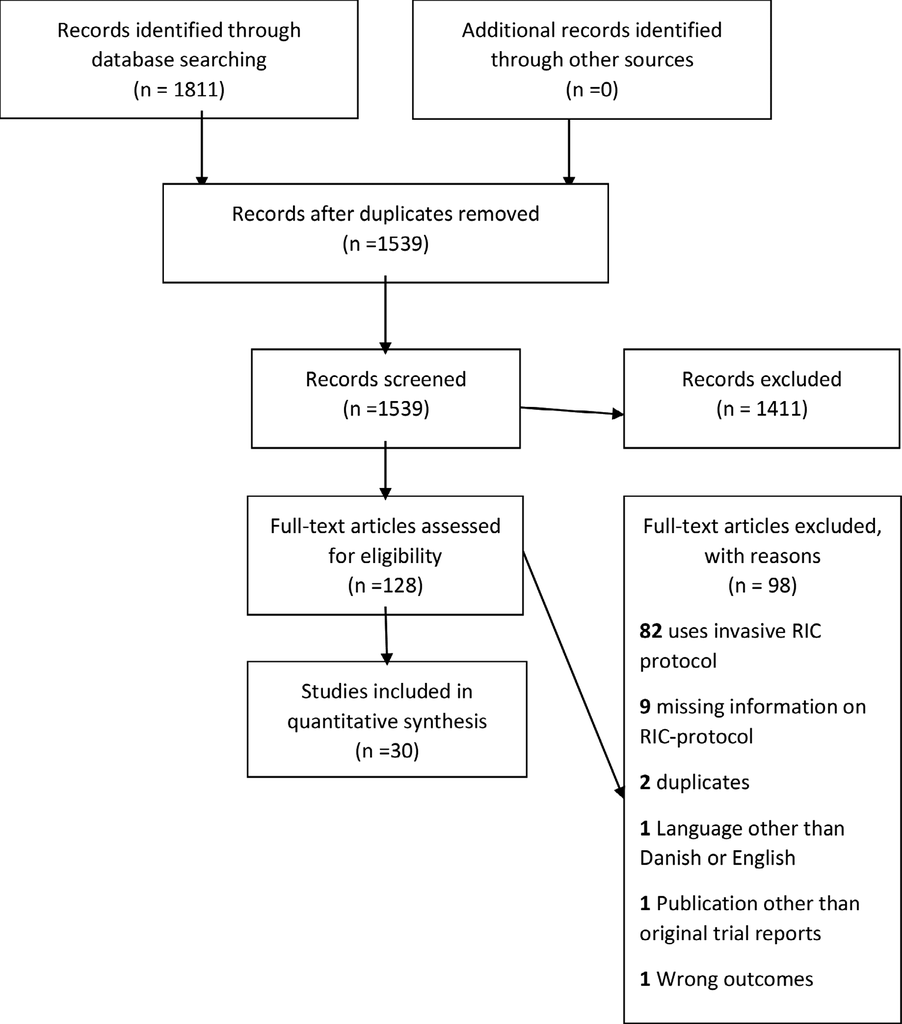

Figure 2. PRISMA ﬂow chart on the selection process in the systematic review.

1722

Translational Challenges of RIC in Stroke

L.F. Hansen et al.

isoﬂurane,<sup>1,3,10,11,22</sup><sup>–</sup><sup>24,30</sup>and two used the structural iso-

mer

enﬂurane.<sup>2,29</sup>

One

study

used

isoﬂurane

and

halothane during the MCAO to determine if either had

additional effects on the outcomes of RIPostC.<sup>24</sup>Sodium

pentobarbital was used prior to inducing RIPostC/sham

procedures in two studies, but the type of anesthesia used

was not reported.<sup>15,16</sup>During post-conditioning proce-

dures, three studies reported the use of ketamine+xylazine

and either propofol,<sup>31</sup>isoﬂurane,<sup>22</sup>or isoﬂurane, respec-

tively.<sup>24</sup>The remaining 13 studies using RIPostC did not

disclose whether RIC procedures were carried out, while

animals were under additional use of anesthesia or if the

control groups were exposed to similar doses and dura-

tions of anesthesia.<sup>1,2,10,11,18</sup><sup>–</sup><sup>21,23,25</sup><sup>–</sup><sup>28</sup>

Of 22 animal studies, six applied RIPerC, 16 applied

RIPostC, and two used a combination of RIPerC and

RIPostC (Table 2). RIPerC studies were performed during

MCAO<sup>3,11,15</sup><sup>–</sup><sup>17,29</sup>or immediately following the introduc-

tion of a ﬁbrinogen clot.<sup>30</sup>The latter study applied RIC

Likewise, one study claimed to investigate RIPostC but

initiated RIC just before reperfusion, thereby almost

resembling RIPerC.<sup>19</sup>Almost all the 16 RIPostC protocols

initiated RIC immediately after reperfusion<sup>2,10,11,18</sup><sup>–</sup><sup>20,25</sup><sup>–</sup>

28,31; only ﬁve protocols delayed the RIPostC.1,21–24 Varia-

tions in the protocol of delayed RIPostC studies disal-

lowed a direct comparison. Two studies initiated single-

session RIPostC at 30<sup>1</sup>and 120<sup>22</sup>min, respectively, after

the completion of MCAO. One study initiated RIPostC at

12 h, 24 h, and 5 days after MCAO, and applied it up to

three times with variable time intervals to investigate very

delayed post-conditioning.<sup>23</sup>Two studies tested consecu-

tive RIPostC; one initiated the protocol for 90 min and

applied RIC for a total of four sessions during the

Table 1. Methods of stroke induction in preclinical RIC studies.

Method

Details of method

Number of

studies (N) and

references

Middle

cerebral

artery

occlusion

(MCAO)

Type of

MCAO

Filament MCAO

(20)<sup>1</sup><sup>–</sup><sup>3,10,11,15</sup><sup>–</sup><sup>29</sup>

Embolic MCAO

(2)<sup>30,31</sup>

Side

Right

(16)<sup>1</sup><sup>–</sup><sup>3,10,15</sup><sup>–</sup><sup>20,25</sup><sup>–</sup>

29,31

Left

(3)<sup>11,21,23</sup>

Not published

(3)<sup>22,24,30</sup>

Duration

30 min

(1)<sup>22</sup>

45 min

(2)<sup>10,11</sup>

60 min

(7)<sup>2,18,23,24,26</sup><sup>–</sup><sup>28</sup>

90 min

(7)<sup>1,15,16,20,21,25,29</sup>

120 min

(3)<sup>3,17,19</sup>

Blood clot – dissolve

time unknown

(2)<sup>30,31</sup>

Anesthesia

under

MCAO

Isoﬂurane/enﬂurane

(8)<sup>1,3,10,11,22</sup><sup>–</sup><sup>24,30</sup>

Enﬂurane

(2)<sup>2,29</sup>

Halothane

(1)<sup>24</sup>

Chloral hydrate

(9)<sup>17</sup><sup>–</sup><sup>21,25</sup><sup>–</sup><sup>28</sup>

Ketamine + propofol

(1)<sup>31</sup>

Not published

(2)<sup>15,16</sup>

Table 2. Procedures for RIC intervention in preclinical studies.

Details of Method

Number of studies (N) and

references

Intervention

Type of RIC tested

RIPerC

(6)<sup>3,11,16,17,29,30</sup>

RIPostC

(16)<sup>1,2,10,11,18</sup><sup>–</sup><sup>28,31</sup>

Combination of RIPerC and RIPostC

(2)<sup>15,16</sup>

Equipment

Tourniquet

(13)<sup>1,3,11,15</sup><sup>–</sup><sup>17,22</sup><sup>–</sup><sup>25,29</sup><sup>–</sup><sup>31</sup>

Rubber bands

(7)<sup>2,18,19,21,26</sup><sup>–</sup><sup>28</sup>

Gauze ropes

(1)<sup>10</sup>

Undisclosed, but non-invasive

(1)<sup>20</sup>

Limb

Unilateral hindlimb

(8)<sup>1,3,11,17,19,22,25,30</sup>

Bilateral hindlimb

(12)<sup>2,10,15,16,18,20,23,24,26</sup><sup>–</sup><sup>29</sup>

Tested both unilateral, bilateral, and multiple

limbs

(1)<sup>31</sup>

Not indicated

(1)<sup>21</sup>

Initiation of RIPostC protocols*

Immediately after MCAO

(11)<sup>2,10,11,18</sup><sup>–</sup><sup>20,25</sup><sup>–</sup><sup>28,31</sup>

30/90/120 min after MCAO

(1)<sup>1</sup>/(1)<sup>24</sup>/(1)<sup>22</sup>

12/24/48/120 h after MCAO

(1),<sup>23</sup>for 48 h (1)<sup>21</sup>

Evaluation of appropriate ischemia

by. . .

Pulse monitoring/Doppler

(7)<sup>1,2,25</sup><sup>–</sup><sup>29</sup>

Clinical evaluation

(7)<sup>3,11,17</sup><sup>–</sup><sup>19,21,30</sup>

Not published

(8)<sup>10,15,16,20,22</sup><sup>–</sup><sup>24,31</sup>

*Describes only RIPostC protocols. RIPerC protocols are all initiated under MCAO,<sup>3,11,15</sup><sup>–</sup><sup>17,29</sup>except one study using a ﬁbrinogen clot; here RIPerC

is initiated 2 h after clot induction.<sup>30</sup>The combinatory (RIPerC + RIPostC) protocols all initiated RIC after 24 h.<sup>15,16</sup>

1723

L.F. Hansen et al.

Translational Challenges of RIC in Stroke

following 72 h<sup>24</sup>and another initiated RIC at 48 h after

reperfusion and applied it daily for 21 consecutive days.<sup>21</sup>

In two studies testing the combination of RIPerC and

RIPostC for 7 or 14 days, the RIPostC regime started

24 h after the MCAO.<sup>15,16</sup>

Most

RIPostC

protocols

investigated

immediate

RIPostC, but the application and number of cycles varied

so the extent of the ischemic response elicited varied

across the experiments.

RIC was mainly applied on hindlimbs, either on one

limb<sup>1,3,11,17,19,22,25,30</sup>

or

more

commonly

bilater-

ally.<sup>2,10,15,16,18,20,23,24,26</sup><sup>–</sup><sup>29</sup>One study did not reveal the

number of limbs subjected to RIC.<sup>21</sup>Effects of RIC

applied on unilateral, bilateral, and multiple limbs were

also compared to explore differences in the efﬁcacy of

RICs based on the number of RIC-affected limbs.<sup>31</sup>

RIC was accomplished using custom-made tourni-

quets,<sup>1,3,11,15</sup><sup>–</sup><sup>17,22</sup><sup>–</sup><sup>25,29</sup><sup>–</sup><sup>31</sup>rubber bands,<sup>2,18,19,21,26</sup><sup>–</sup><sup>28</sup>and

gauze ropes.<sup>10</sup>In one study, the authors only stated that

RIC

was

performed

non-invasively.<sup>20</sup>

Complete

limb

ischemia was conﬁrmed using monitoring or Doppler

ultrasound equipment to detect the loss of pulse or

ﬂow<sup>1,2,25</sup><sup>–</sup><sup>29</sup>or clinical evaluation.<sup>3,11,17</sup><sup>–</sup><sup>19,21,30</sup>More than

one-third of the studies omitted how adequate ischemia

was ensured.<sup>10,15,16,20,22</sup><sup>–</sup><sup>24,31</sup>

The number of cycles and the occlusion/reperfusion

time in RIC sessions differed between studies (Table 3).

The most commonly applied protocol (N = 9) comprised

three cycles of 10 min of occlusion interspersed with

10 min of deﬂation.<sup>2,10,18,20,23,26</sup><sup>–</sup><sup>29</sup>Most studies adminis-

tered RIC as a single session; only ﬁve studies applied

multiple RIC sessions.<sup>15,16,21,23,24</sup>Studies testing multiple

RIC applications or combinations of RIPerC and RIPostC

differed

in

RIC

application

protocol

and

follow-up

periods.

Most studies were performed in rats,<sup>1,3,15</sup><sup>–</sup><sup>21,25</sup><sup>–</sup><sup>29</sup>seven

studies used mice<sup>2,10,11,22</sup><sup>–</sup><sup>24,30</sup>and one study included

primates<sup>31</sup>(Table S1). Most studies used males,<sup>2,3,10,11,15</sup><sup>–</sup>

17,19–21,23–25,29,31 four studies used females,26–28,30 and one

study included both sexes.<sup>22</sup>Two studies did not disclose

the sex of the investigated animals.<sup>1,18</sup>Only two studies

investigated RIC in non-healthy animals, one in ovariec-

tomized female mice,<sup>30</sup>and one in diabetic rats.<sup>10</sup>

Trial designs were challenged by several important

issues such as information on randomization; only one of

the 22 studies described randomization procedures,<sup>29</sup>

some

claimed

randomization

but

gave

no

further

details,<sup>3,18,19,22</sup><sup>–</sup><sup>26,28</sup>and others described randomization

as groups formed by randomly selecting animals from

cages.<sup>2,27,30</sup>Nine studies did not inform on randomiza-

tion to groups.<sup>1,10,11,15</sup><sup>–</sup><sup>17,20,21,31</sup>Most studies reported

blinding

was

applied

for

parts

of

the

data

analy-

sis.<sup>1,3,10,11,15</sup><sup>–</sup><sup>24,26</sup><sup>–</sup><sup>31</sup>

Methods applied in human trials

Eight stroke patient trials were eligible for this review. In

four studies, the effect of RIC was investigated in patients

who were not eligible for revascularization therapies.<sup>32</sup><sup>–</sup><sup>35</sup>

In three studies, RIC was applied as an add-on for treat-

ments of thrombolysis by intravenous alteplase<sup>36,37</sup>or

thrombectomy.<sup>38</sup>One study included patients receiving

additional medical treatment and patients not eligible for

thrombolysis or thrombectomy.<sup>39</sup>None of the included

studies used a comparable study protocol and/or follow-

up period, so the results of the individual studies remain

unconﬁrmed.

Of three studies including patients who received revas-

cularization therapy, only one tested single-session RIC

on patients during transport to the stroke unit for throm-

bolysis.<sup>37</sup>The second study administered RIPerC within

2 h after the administration of thrombolysis, followed by

twice-a-day RIC sessions for a total of 7 days.<sup>36</sup>The third

study combined RIPerC followed by RIPostC for 7 days

to patients who received endovascular thrombectomy

treatment within 6 h of the onset of stroke.<sup>38</sup>

Studies of patients who did not undergo additional

revascularization initiated RIC within 24 h from stroke

onset<sup>32</sup>or 24–72 h (with subsequent daily sessions up to

14 days<sup>33</sup>). Two studies did not indicate when RIC was

initiated,<sup>34,35</sup>revealing only that one inclusion criterion

was a symptom onset between 4.5 h and 14 days prior to

the initiation of RIC.<sup>35</sup>The study that included patients

with and without additional medical revascularization

included patients within 6 h from disease onset and had

three groups. Each group received one RIC session, two

RIC sessions 1 h apart, or RIC sessions twice daily for

4 days from ictus.<sup>39</sup>

In two studies, protocols comprised ﬁve cycles of

5 min of inﬂation and 5 min of deﬂation of a tourniquet,

Table 3. RIC protocols used in the included preclinical studies.

Protocol

Number

of cycles

Inﬂation/

deﬂation

(minutes)

Number of studies (N)

and references

Single

session

RIPerC/

RIPostC

3

5/5

(2)<sup>1,25</sup>

10/10

(8)<sup>2,10,18,20,26</sup><sup>–</sup><sup>29</sup>

15/15

(1)<sup>19</sup>

4

5/5

(3)<sup>3,11,17</sup>

10/10

(1)<sup>30</sup>

5

5/5

(1)<sup>22</sup>

10

5/5

(1)<sup>31</sup>

Repeated

RIPostC

3

5/5

(2)<sup>21,24</sup>

3

10/10

(1)<sup>23</sup>

Combination

3

10/10

(2)<sup>15,16</sup>

1724

Translational Challenges of RIC in Stroke

L.F. Hansen et al.

5 days a week for 8 weeks in total,<sup>34</sup>or one daily RIC for

6 months.<sup>35</sup>These protocols are in contrast to remaining

studies in which each RIC session comprised only four

cycles with 5 min of inﬂation and 5 min of deﬂa-

tion.<sup>32,33,36</sup><sup>–</sup><sup>39</sup>

The clinical trials mainly applied RIC to a single upper

extremity; ﬁve studies performed RIC on the non-paretic

arm<sup>32</sup><sup>–</sup><sup>35,39</sup>and two studies did not specify on which arm

the intervention occurred.<sup>37,38</sup>One study performed RIC

bilaterally on upper limbs but due to the administration

of intravenous ﬂuids or blood pressure cuffs, not all

cycles were performed bilaterally. No information was

disclosed regarding the number of patients who did not

receive all cycles of bilateral RIC or the impact on data

analysis.<sup>36</sup>

Overall, RIC protocols of clinical studies differed in the

type of RIC, number of affected limbs, initiation, repeti-

tion, time periods, and completing all intended cycles.

Studies offering data on completion showed rate ranges

of 40%–97%.<sup>32,36</sup><sup>–</sup><sup>39</sup>One study described that not all

cycles were completed, but did not include data on the

number of completed cycles.<sup>33</sup>Two studies also failed to

report the number of completed cycles, but had the most

the ambulance discontinued the intervention upon arrival

to the stroke unit, leading to the lowest published com-

pletion rate of included studies, with only 33 of 81

patients receiving the intended number of cycles.<sup>37</sup>None

of the studies reported a possible bias of non-completed

cycles in their data analysis.<sup>32</sup><sup>–</sup><sup>39</sup>

There was a male preponderance of 52%–80% in seven

studies.<sup>32,34</sup><sup>–</sup><sup>39</sup>One study did not disclose the gender dis-

tribution.<sup>33</sup>Unlike preclinical studies, clinical studies

commonly had an intervention group with multiple

known stroke risk factors like smoking, hypertension, and

obesity.<sup>32</sup><sup>–</sup><sup>39</sup>

three

of

which

were

placebo

con-

study did not inform on blinding,<sup>35</sup>and the remaining

study did not include controls, randomization, or blind-

ing.<sup>38</sup>

Discussion

Based on the preclinical data in animals and clinical data

in humans identiﬁed in our review, we found multiple

important discrepancies in the design and performance of

the RIC protocols that could be barriers in the translation

of results. Important differences were (1) preclinical stud-

ies applied RIC on hindlimbs representing a larger muscle

mass than that of forearm occlusion applied in humans,

(2) the need for the use of anesthetics in animal studies,

(3) lack of relevant comorbidities in animals used for

testing, and (4) no homogeneity of timing, number, dura-

tion, or repetition of RIC in animal or human studies.

These signiﬁcant differences in methodology may account

for the poor translation of otherwise promising preclinical

Failing to translate positive results from animals to

human clinical trials is a well-known phenomenon. To

reduce the risk of pitfalls in the process of translation, the

Stroke Treatment Academic Industry Roundtable (STAIR)

recommendations<sup>6</sup>on preclinical trials were formulated.

STAIR recommendations describe the importance of con-

sidering the choice of species and gender, proposed mech-

anism of action of treatment, and how to incorporate

human comorbid conditions into preclinical trials. In

research on cardioprotection, a four-step process was

identiﬁed by Rossello and Yellon to improve the transla-

tion of data.<sup>40</sup>Similar steps could be applicable in neuro-

science translational research to help identify gaps in

current knowledge, which may improve outcomes in

future clinical trials (Fig. 3).

Studies included in this review suffer from pitfalls

addressed in both the STAIR recommendations and in

identiﬁed steps on translational studies in cardioprotec-

tion.

In preclinical studies, transient ﬁlament MCAO with

variable occlusion time was the most frequently applied

method for stroke induction, with only two exceptions

that applied the embolic MCAO model.<sup>30,31</sup>In contrast to

clinical stroke, the MCAO ﬁlament model used in animal

experiments offers immediate brain ischemia and com-

plete reperfusion of blood ﬂow when terminated.<sup>15,16,29</sup>

This fast return of perfusion resembles the clinical situa-

tion of patients receiving endovascular thrombectomy

treatment or thrombolysis. However, the method bears

little resemblance to the clinical situation of patients who

experience ischemic stroke with spontaneous dissolving

clots and reperfusion. Furthermore, introducing the ﬁla-

ment through the arteries may induce signiﬁcant mechan-

ical endothelial damage not equivalent to human stroke.

An animal model that mimics focal cerebral ischemia

with gradual reperfusion, as is expected to occur in

human ischemic stroke, has yet to be found. Although

normal ﬁlament MCAO may be the best preclinical

method to investigate conditions resembling those in

patients receiving reperfusion therapy, animal models that

apply a modiﬁed blood clot<sup>30,31</sup>may be preferred when

exploring conditions similar to stroke patients not eligible

for revascularization procedures, but not to those with

minor strokes.

1725

L.F. Hansen et al.

Translational Challenges of RIC in Stroke

Most preclinical trials administered RIPostC immedi-

ately after reperfusion, primarily mimicking the small

group of patients undergoing abrupt reperfusion therapies

in acute stroke. Testing effects of delayed conditioning is

perhaps more interesting for future treatment because not

all arrive in a timely fashion or are eligible for revascular-

ization therapy. Unfortunately, the few studies that tested

a delayed application of RIC all applied different RIC

protocols, leaving their conclusions unconﬁrmed.<sup>1,15,16,21</sup><sup>–</sup>

24 Studies testing and conﬁrming the effect of delayed

RIC from animal studies, could have huge translational

potential and become important in clinical treatment.

Another important challenge of the animal models is

using isoﬂurane or enﬂurane as anesthetics during MCAO

and while administering RIPostC. Isoﬂurane is a potential

confounder as decreases excitotoxicity and improves func-

tional and histological outcomes<sup>41</sup><sup>–</sup><sup>43</sup>in stroke. One study

investigated a possible difference in outcome after using

RIC on animals subjected to isoﬂurane anesthesia under

MCAO and under RIC compared to halothane MCAO

and ketamine-xylazine RIC and concluded that both anes-

thetics might have inﬂuenced the results.<sup>24</sup>Thus, even

though volatile anesthetics are easy to handle and have

rapid effects, they should be avoided in experimental

stroke research. An alternative could be the use of choral

hydrate.<sup>17</sup><sup>–</sup><sup>21,25</sup><sup>–</sup><sup>28</sup>

Common to many studies is a discrepancy in the extent

of remote ischemia induced by the RIC protocol in terms

of the amount of afﬂicted tissue subjected to ischemia

and length of RIC number of repeated cycles. All human

studies performed RIC on upper limbs and, with only

one exception,<sup>31</sup>all animal trials applied RIC unilaterally

or bilaterally on hindlimbs. The hindlimb of any animal

(mouse, rat, or primate), represents a larger muscle mass

than that of an arm in a human, thereby increasing the

relative amount of induced ischemia. In primates, the

optimal number of limbs subjected to RIC was a two-

limb protocol, which elicited a greater effect than a one-

limb protocol; a four-limb protocol had no additional

effect.<sup>31</sup>This is an interesting and important ﬁnding, but

all human trials except one conducted RIC on only one

upper extremity. The study that intended to provide RIC

bilaterally failed and did not disclose the level of fulﬁll-

ment or how it may have affected the results.

The number and length of RIC cycles varied greatly in

animal studies (Table 3), whereas the preferred protocol

in humans consisted of four cycles of 5 min of occlusion

interspersed by 5 min of reperfusion. None of the human

trials succeeded in applying the intended RIC protocol;

trials had low completion rates that were not taken into

account

in

the

data

analysis

and

interpretation

of

results.<sup>32,33,37,38</sup>A recent study published following the

completion of our ﬁnal search reported to complete all

intended cycles but reported no clinical effect of RIC.<sup>44</sup>

There are currently no animal or human studies that

have aimed to deﬁne the optimal number of cycles of

occlusion/deﬂation time and still have a translatable RIC

protocol. Although RIC was achieved non-invasively by

tightening a rubber band, gauze rope, or a tourniquet,

only a few preclinical trials assured complete ischemia of

the limb (e.g., by using pulse monitoring) to conﬁrm a

uniform ischemic response in the subjects.

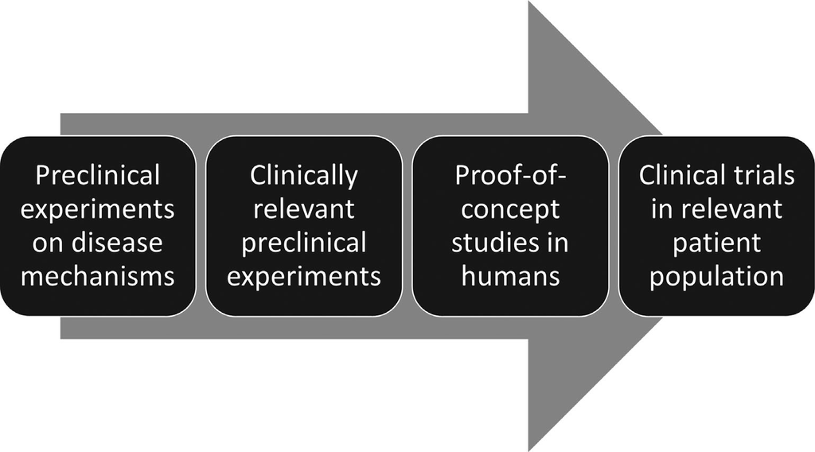

Figure 3. Investigations of RIC effects in stroke partly omit the essential intermediate steps 2 and 3 in the process of translation suggested by

Rossello and Yellon.<sup>40</sup>

1726

Translational Challenges of RIC in Stroke

L.F. Hansen et al.

It is evident that the ischemic response induced in pre-

clinical studies is larger than those induced in human tri-

als. This ﬁnding warrants new experiments in which the

amount of administered RIC is more comparable. This

approach could be achieved if RIC was induced on the

upper limbs in preclinical trials or if RIC was adminis-

tered on legs or bilaterally on arms in clinical trials, and

by considering the number and length of obtained RIC

sessions in data analysis.

Another pitfall was to include animals that are not

comparable to relevant patient populations. Studies are

needed that test RIC in animals with known risk fac-

tors

that

are

characteristic

for

stroke

patients

(i.e.,

hypertension,

diabetes,

atrial

ﬁbrillation)

to

properly

estimate the effect of RIC in stroke. Few studies tested

non-invasive RIC in animals with risk factors,<sup>10,30</sup>but

data from both pre-conditioning protocols and invasive

RIC experiments suggest that risk factors impact the

effectiveness of RIC.<sup>45</sup>This translational gap under-

scores the need for animal studies to investigate possi-

ble confounders when evaluating a beneﬁcial effect of

RIC

in

stroke

patients.

Preclinical

RIC

experiments

should also include multiple species, including gyren-

cephalic species in which anatomy and physiology show

stronger resemblance to humans, which has only been

performed in one study.<sup>31</sup>

Rigor, reproducibility, and clinical feasibility, the main

pillars of translational research, decrease the risk of bias

and confounders and increase translational potential. In

the animal experiments reviewed, the use of randomiza-

tion and a thorough description of how randomization

was performed was only included in one of 22 studies.<sup>29</sup>

The inconsistency in using true randomization greatly

increases

the

risk

of

bias

and

false-positive

results,

decreasing the rigor and reproducibility of the studies.

Similar pitfalls apply in human studies reviewed, in which

only three of the eight studies used placebo in the control

group and all were open-labeled. Importantly, both ran-

domization and blinding of evaluators were common in

the human trials.

In addition to the RIC methods applied, which is the

scope of the current review, major pitfalls may also lie in

the selection of endpoints, like infarct size and neurologi-

cal scores. Both infarct size and behavioral scoring were

often evaluated only 24 h from stroke induction; thus,

long-term effects could not be determined. More work

needs to be performed to harmonize the use of preclinical

and clinical outcome measures.

Conclusion

A translational gap exists in understanding the effects of

RIC in stroke. Most preclinical studies use methods that

are not applicable in acute stroke treatment in humans.

We found only 22 studies that investigated RIC for acute

treatment. Major methodological differences that decrease

the translational potential of preclinical studies (e.g., use

of healthy male rats and undergoing MCAO under the

inﬂuence of confounding anesthesia) were revealed in

diverse RIC protocols. There were no studies that deter-

mined optimal RIC protocol on the length, number of

cycles, repetition, or time of initiation. Human trials were

challenged by the non-completion of intended protocols

and by not addressing this problem in data analysis.

Future animal studies on RIC should incorporate

STAIR recommendations when planning and executing

preclinical trials and determine clinically relevant end-

points. Human trials should strive to apply intended

cycles of RIC and consider optimal RIC protocols and

applications resembling those performed in positive pre-

clinical trials.

Acknowledgment

CK was supported by a grant from Novo Nordisk Foun-

dation (Borregaard Stipend, NNF18OC0031840), LC was

supported by a research scholarship from Lundbeck

Foundation.

Conﬂict of Interest

The authors have no conﬂict of interest except for grants

mentioned in acknowledgments.

References

1. Bonova P, Gottlieb M. Blood as the carrier of ischemic

tolerance in rat brain. J Neurosci Res 2015;93:1250–1257.

2. Cheng X, Zhao H, Yan F, et al. Limb remote ischemic

post-conditioning mitigates brain recovery in a mouse

model of ischemic stroke by regulating reactive astrocytic

plasticity. Brain Res 2018;1686:94–100.

3. Hahn CD, Manlhiot C, Schmidt MR, et al. Remote

ischemic per-conditioning: a novel therapy for acute

stroke? Stroke 2011;42:2960–2962.

4. World Health Organization. WHO - The top 10 causes of

death [Internet]. 24 Maggio 2018;1–7. [cited 2020 Apr 23].

Available from: http://www.who.int/en/news-room/fact-

sheets/detail/the-top-10-causes-of-death

5. Zhao W, Zhang J, Sadowsky MG, et al. Remote ischaemic

conditioning for preventing and treating ischaemic stroke.

Cochrane Database Syst Rev 2018;7:CD012503.

6. Kahle MP, Bix GJ. Successfully climbing the “STAIRs”:

surmounting failed translation of experimental ischemic

stroke treatments. Stroke Res Treat 2012;2012:8.

7. Healy DA, Clarke Moloney M, McHugh SM, et al. Remote

ischaemic preconditioning as a method for perioperative

1727

L.F. Hansen et al.

Translational Challenges of RIC in Stroke

cardioprotection: concepts, applications and future

directions. Int J Surg 2014;12:1093–1099.

8. Sprick JD, Mallet RT, Przyklenk K, Rickards CA.

Ischaemic and hypoxic conditioning: potential for

protection of vital organs. Exp Physiol 2019;104:278–294.

9. Hausenloy DJ, Yellon DM. Ischaemic conditioning and

reperfusion injury. Nat Rev Cardiol 2016;13:193–209.

10. Liu C, Yang J, Zhang C, et al. Remote ischemic

conditioning reduced cerebral ischemic injury by

modulating inﬂammatory responses and ERK activity in

type 2 diabetic mice. Neurochem Int 2020;135:104690.

11. Kitagawa K, Saitoh M, Ishizuka K, Shimizu S. Remote

limb ischemic conditioning during cerebral ischemia

reduces infarct size through enhanced collateral circulation

in murine focal cerebral ischemia. J Stroke Cerebrovasc

Dis 2018;27:831–838.

12. Ma D, Feng L, Deng F, Feng J. Overview of experimental

and clinical ﬁndings regarding the neuroprotective effects

of cerebral ischemic postconditioning. Biomed Res Int

2017;2017:6891645.

13. Hess DC, Blauenfeldt RA, Andersen G, et al. Remote

ischaemic conditioning-a new paradigm of self-protection

in the brain. Nat Rev Neurol 2015;11:698–710.

14. Moher D, Liberati A, Tetzlaff J, Altman DG. Preferred

reporting items for systematic reviews and meta-analyses:

the PRISMA statement. PLoS Med 2009;6:e1000097.

15. Ren C, Li S, Wang B, et al. Limb remote ischemic

conditioning increases Notch signaling activity and

promotes arteriogenesis in the ischemic rat brain. Behav

Brain Res 2018;340:87–93.

16. Ren C, Wang P, Wang B, et al. Limb remote ischemic

per-conditioning in combination with post-conditioning

reduces brain damage and promotes neuroglobin

expression in the rat brain after ischemic stroke. Restor

Neurol Neurosci 2015;33:369–379.

17. Wang J, Han D, Sun M, Fen J. A combination of remote

ischemic perconditioning and cerebral ischemic

postconditioning inhibits autophagy to attenuate plasma

HMGB1 and induce neuroprotection against stroke in rat.

J Mol Neurosci 2016;58:424–431.

18. Zong Y, Jiang L, Zhang M, et al. Limb remote ischemic

postconditioning protects cerebral ischemia from injury

associated with expression of HIF-1aalpha in rats. BMC

Neurosci 2015;16:1.

19. Chen G, Shan X, Li X, Tao H. Remote ischemic

postconditioning protects the brain from focal ischemia/

reperfusion injury by inhibiting autophagy through the

mTOR/p70S6K pathway. Neurol Res 2018;40:182–188.

20. Huang D, Liu H, Qu Y, Wang P. Non-invasive remote

ischemic postconditioning stimulates neurogenesis during

the recovery phase after cerebral ischemia. Metab Brain

Dis 2017;32:1805–1818.

21. Liang D, He XB, Wang Z, et al. Remote limb ischemic

postconditioning promotes motor function recovery in a

rat model of ischemic stroke via the up-regulation of

endogenous tissue kallikrein. CNS Neurosci Ther

2018;24:519–527.

22. Yang J, Balkaya M, Beltran C, et al. Remote postischemic

conditioning promotes stroke recovery by shifting

circulating monocytes to CCR2(+) proinﬂammatory

subset. J Neurosci 2019;39:7778–7789.

23. Doeppner TR, Zechmeister B, Kaltwasser B, et al. Very

delayed remote ischemic post-conditioning induces

sustained neurological recovery by mechanisms involving

enhanced angioneurogenesis and peripheral

immunosuppression reversal. Front Cell Neurosci

2018;12:383.

24. Chen G, Kamat PK, Ahmad AS, Dore S. Distinctive effect

of anesthetics on the effect of limb remote ischemic

postconditioning following ischemic stroke. PLoS One

2020;15:e0227624.

25. Cheng Z, Li L, Mo X, et al. Non-invasive remote limb

ischemic postconditioning protects rats against focal

cerebral ischemia by upregulating STAT3 and reducing

apoptosis. Int J Mol Med 2014;34:957–966.

26. Li J, Hu XS, Zhou FF, et al. Limb remote ischemic

postconditioning protects integrity of the blood-brain

barrier after stroke. Neural Regen Res 2018;13:1585–1593.

27. Li S, Hu X, Zhang M, et al. Remote ischemic post-

conditioning improves neurological function by AQP4

down-regulation in astrocytes. Behav Brain Res

2015;289:1–8.

28. Qi W, Zhou F, Li S, et al. Remote ischemic

postconditioning protects ischemic brain from injury in

rats with focal cerebral ischemia/reperfusion associated

with suppression of TLR4 and NF-kappaB expression.

NeuroReport 2016;27:469–475.

29. Ren C, Li N, Wang B, et al. Limb ischemic

perconditioning attenuates blood-brain barrier disruption

by inhibiting activity of MMP-9 and occludin degradation

after focal cerebral ischemia. Aging Dis 2015;6:406–417.

30. Hoda MN, Bhatia K, Hafez SS, et al. Remote ischemic

perconditioning is effective after embolic stroke in

ovariectomized female mice. Transl Stroke Res 2014;5:484–

490.

31. Guo L, Zhou DA, Wu DI, et al. Short-term remote

ischemic conditioning may protect monkeys after ischemic

stroke. Ann Clin Transl Neurol 2019;6:310–323.

32. England TJ, Hedstrom A, O’Sullivan S, et al. RECAST

(remote ischemic conditioning after stroke trial): a pilot

randomized placebo controlled phase II trial in acute

ischemic stroke. Stroke 2017;48:1412–1415.

33. Li Y, Liang K, Zhang L, et al. Upper limb ischemic

postconditioning as adjunct therapy in acute stroke

patients: a randomized pilot. J Stroke Cerebrovasc Dis

2018;27:3328–3335.

34. Ji Z, Yu L, Wu W, Fang Q. Remote ischemic

postconditioning promotes collateral circulation and

1728

Translational Challenges of RIC in Stroke

L.F. Hansen et al.

down-regulates TLR4/NF-kappaB signaling pathway in

patients with acute ischemic stroke. Int J Clin Exp Med

2020;13(1 PG-246–252):246–252.

35. Feng X, Huang L, Wang Z, et al. Efﬁcacy of remote limb

ischemic conditioning on poststroke cognitive impairment.

J Integr Neurosci 2019;18(4 PG-377–385):377–385.

36. Che R, Zhao W, Ma Q, et al. rt-PA with remote ischemic

postconditioning for acute ischemic stroke. Ann Clin

Transl Neurol 2019;6:364–372.

37. Hougaard KD, Hjort N, Zeidler D, et al. Remote ischemic

perconditioning as an adjunct therapy to thrombolysis in

patients with acute ischemic stroke: a randomized trial.

Stroke 2014;45:159–167.

38. Zhao W, Che R, Li S, et al. Remote ischemic conditioning

for acute stroke patients treated with thrombectomy. Ann

Clin Transl Neurol 2018;5:850–856.

39. England TJ, Hedstrom A, O’Sullivan SE, et al. Remote

ischemic conditioning after stroke trial 2: a phase IIb

randomized controlled trial in hyperacute stroke. J Am

Heart Assoc 2019;8:e013572.

40. Rossello X, Yellon DM. Cardioprotection: the disconnect

between bench and bedside. Circulation 2016;134:574–575.

41. Hoffmann U, Sheng H, Ayata C, Warner DS. Anesthesia

in experimental stroke research. Transl Stroke Res

2016;7:358–367.

42. Li H, Yin J, Li L, et al. Isoﬂurane postconditioning

reduces ischemia-induced nuclear factor-kappaB activation

and interleukin 1beta production to provide

neuroprotection in rats and mice. Neurobiol Dis

2013;54:216–224.

43. Taheri S, Shunmugavel A, Clark D, Honglian S. Isoﬂurane

reduces the ischemia reperfusion injury surge: a

longitudinal study with MRI. Brain Res 2014;1586:173–

183.

44. He Y, Guo Z, Qin C, et al. Remote ischemic conditioning

combined with intravenous thrombolysis for acute

ischemic stroke. Ann Clin Transl Neurol 2020;7:972–979.

45. McCafferty K, Forbes S, Thiemermann C, Yaqoob MM.

The challenge of translating ischemic conditioning from

animal models to humans: the role of comorbidities. Dis

Model Mech 2014;7:1321–1333.

Supporting Information

Additional supporting information may be found online

in the Supporting Information section at the end of the

article.

Figure S1. Schematic illustration of search string.

Figure S2. Detailed MEDLINE and Embase search string.

Table S1. Species and trial design in animal studies.

Table S2. Overview of the included 22 animal studies.

Table S3. Overview of the included eight human trials.

1729

L.F. Hansen et al.

Translational Challenges of RIC in Stroke